# Test a Perceptual Phenomenon

### Analyzing the Stroop Effect

Perform the analysis in the space below. Remember to follow [the instructions](https://docs.google.com/document/d/1-OkpZLjG_kX9J6LIQ5IltsqMzVWjh36QpnP2RYpVdPU/pub?embedded=True) and review the [project rubric](https://review.udacity.com/#!/rubrics/71/view) before submitting. Once you've completed the analysis and write-up, download this file as a PDF or HTML file, upload that PDF/HTML into the workspace here (click on the orange Jupyter icon in the upper left then Upload), then use the Submit Project button at the bottom of this page. This will create a zip file containing both this .ipynb doc and the PDF/HTML doc that will be submitted for your project.

(1) What is the independent variable? What is the dependent variable?

Dependent variables: word meaning and ink color. If word meaning matches the ink color, respond times are faster. Independent variables: ink and respond time.

(2) What is an appropriate set of hypotheses for this task? Specify your null and alternative hypotheses, and clearly define any notation used. Justify your choices.

The appropiate hypothesis for this task would be:

$$H_0: \mu_{incongr} - \mu_{congr} \leq 0$$$$H_0: \mu_{incongr} - \mu_{congr} > 0$$

Null hypothesis says that average time to finish incongruent word part is not greater than or equal to average congruent word part. Alternate hypothesis say exact opposite. During the statistical analysis, the alternative hypothesis will be checked is it true or not.

For these analysis we will use bootstraping method on null hypothesis in order to check if we can reject it or not. If results will show that we can reject null hypothesis it means that alternative hypothesis would be statistically correct.

However, we have to be careful when drawing conclusions using the results.A deep knowledge about the field and used metrics is required, because sometimes data doesn't actually reflect real word senarios that you associate with .(For example: bigger spent times in sales website, doesn't mean that it indicates the higher sales for that website. Especially if layout of the website has been just changed.).Another drawback, this method requires certain amount of sample data, to ensure correct resutls.

(3) Report some descriptive statistics regarding this dataset. Include at least one measure of central tendency and at least one measure of variability. The name of the data file is 'stroopdata.csv'.

```python
import pandas as pd
import numpy as np
import random
import matplotlib.pyplot as plt
%matplotlib inline

df = pd.read_csv('stroopdata.csv')
print(df.describe())
print('\n', df.median())
```

```
       Congruent  Incongruent
count  24.000000    24.000000
mean   14.051125    22.015917
std     3.559358     4.797057
min     8.630000    15.687000
25%    11.895250    18.716750
50%    14.356500    21.017500
75%    16.200750    24.051500
max    22.328000    35.255000

 Congruent      14.3565
Incongruent    21.0175
dtype: float64
```

Looking to mean and median values we can say:

Data variability shows that every variability value (minimum, maximum values, 25%, 50%, 75%, percentile) is higher in Incongruent column. That tell us that, statistically, incongruent word times are higher across whole data distribution.

(4) Provide one or two visualizations that show the distribution of the sample data. Write one or two sentences noting what you observe about the plot or plots.

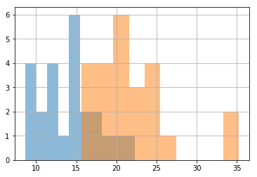

```python
df.Congruent.hist(alpha=0.5);
df.Incongruent.hist(alpha=0.5);
```

(5) Now, perform the statistical test and report your results. What is your confidence level or Type I error associated with your test? What is your conclusion regarding the hypotheses you set up? Did the results match up with your expectations? **Hint:** Think about what is being measured on each individual, and what statistic best captures how an individual reacts in each environment.

```python
congr_mean = df.Congruent.mean()
```

```python
incongr_mean = df.Incongruent.mean()
```

```python
obs_diff = incongr_mean - congr_mean
```

```python
# Create sampling distribution for difference in completion rates
# with boostrapping
diffs = []
for _ in range(10000):
    samp = df.sample(df.shape[0], replace=True)
    congr_s = samp.Congruent.mean()
    incongr_s = samp.Incongruent.mean()
    diffs.append(incongr_s - congr_s)
```

```python
# convert to numpy array
diffs = np.array(diffs)
```

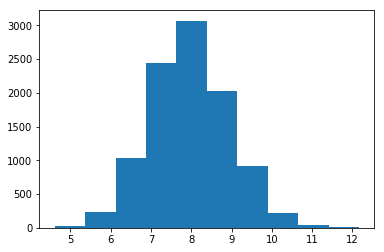

```python
# plot distribution
plt.hist(diffs);
```

```python
# create distribution under the null hypothesis
null_vals = np.random.normal(0, diffs.std(), diffs.size)
```

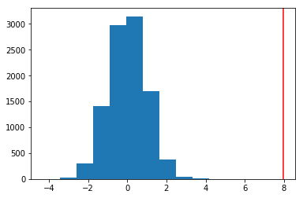

```python
# plot null distribution
plt.hist(null_vals);

# plot line for observed statistic
plt.axvline(obs_diff, c='red');
```

```python
# compute p value
(null_vals > obs_diff).mean()
```

```
0.0
```

For this analysis we select Type I error of 5%. According to te error rate our hypothesis now looks like this:

$$H_0: \mu_{incongr} - \mu_{congr} \leq 0.05$$$$H_0: \mu_{incongr} - \mu_{congr} > 0.05$$

As we can see p value equals to 0 and its below of our type I error rate 0.05. This indicates that we can statistically reject null hypothesis and say that alternative hypothesis (incogruent part test times are higher) is statistically more likely to happen.This results was expected, because average times and time distributions were supporting this hypothesis.

(6) Optional: What do you think is responsible for the effects observed? Can you think of an alternative or similar task that would result in a similar effect? Some research about the problem will be helpful for thinking about these two questions!

The text have a strong influence over human reaction to say the color. The interference between the different information (what the words say and the color of the words) human brain receives causes a problem. There are three theories that may explain the Stroop effect:

- Speed of Processing Theory: the interference occurs because words are read faster than colors are named.
- Selective Attention Theory: the interference occurs because naming colors requires more attention than reading words.
- Automatic Word Recognition Hypothesis: human brain automatically reads words first, which cause interference when words and colors doesn't match.

However my hypothesis would be that child that knows colors, but don't know how to read, would have the similar results in both parts of the test.